# pilots_explore

# 1 Description:

Ran 3 participants on the schema consistent condition.

3 schema learning sessions, 1 new PA session.

10 trials for each PA, for each session.

3 seconds to respond, with feedback afterwards.

# 2 Exact vs rough accuracy:

One quickly gets a good feeling of roughly where the items are, but its hard to click the exact cell. So, I also measure “roughly correct” outcome, where the participant was off by 1 cell.

Participant 48652 (1st row in the plots) had 6 old PAs and 6 new PAs (6/6 for short). Participant zibzab had 6/6, but with a larger board so responding should have been easier. Participant notmyname had 8/6, so 8 old PAs and 6 new PAs, on a large board.

Seems like everyone roughly learns the location of the items, but clicking the precise cell is hard.

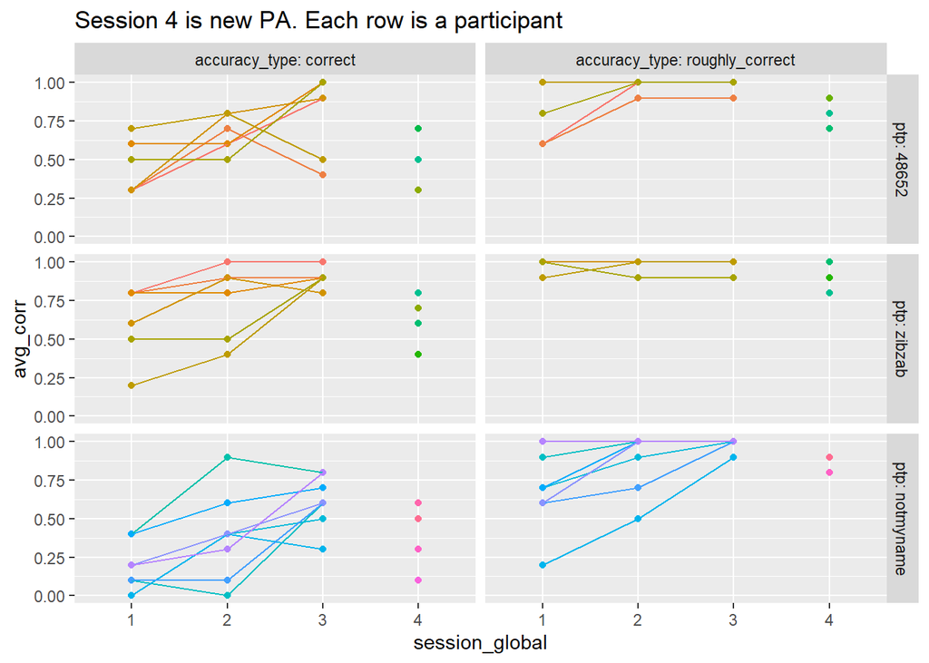

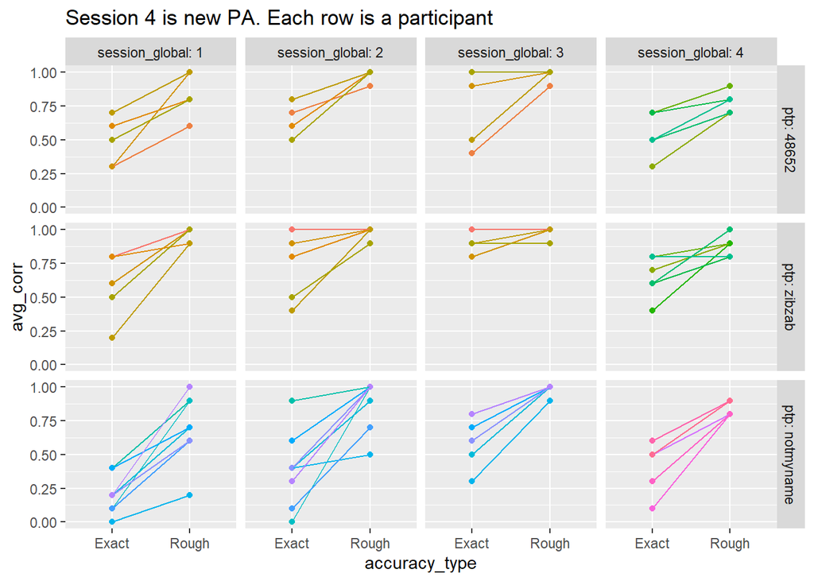

# 3 Heatmaps:

One figure for each participant. Within each figure, the left panel is schema learning, the right panel is new PA learning.

Each row is a separate PA stimulus.

red X marks the location of the target PA. Cyan Xs mark locations of other PAs.

Conclusions:

For schema learning, I think all the participants show good rough knowledge by session 3. The participant “notmyname” struggles with a few stimuli because there were 8 of them.

For new PA learning, I tried looking at whether performance depended on being close to an old PA or not, but with just 3 participants its hard to say.

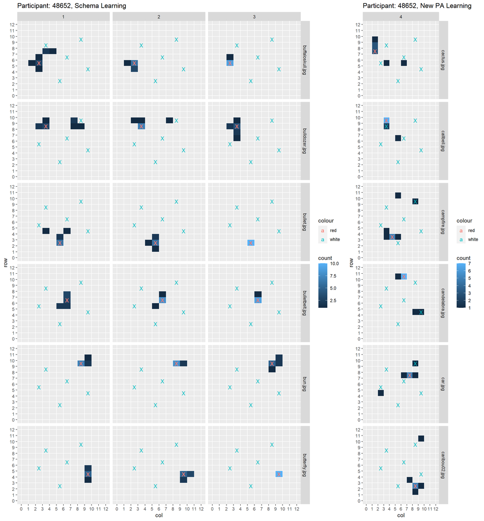

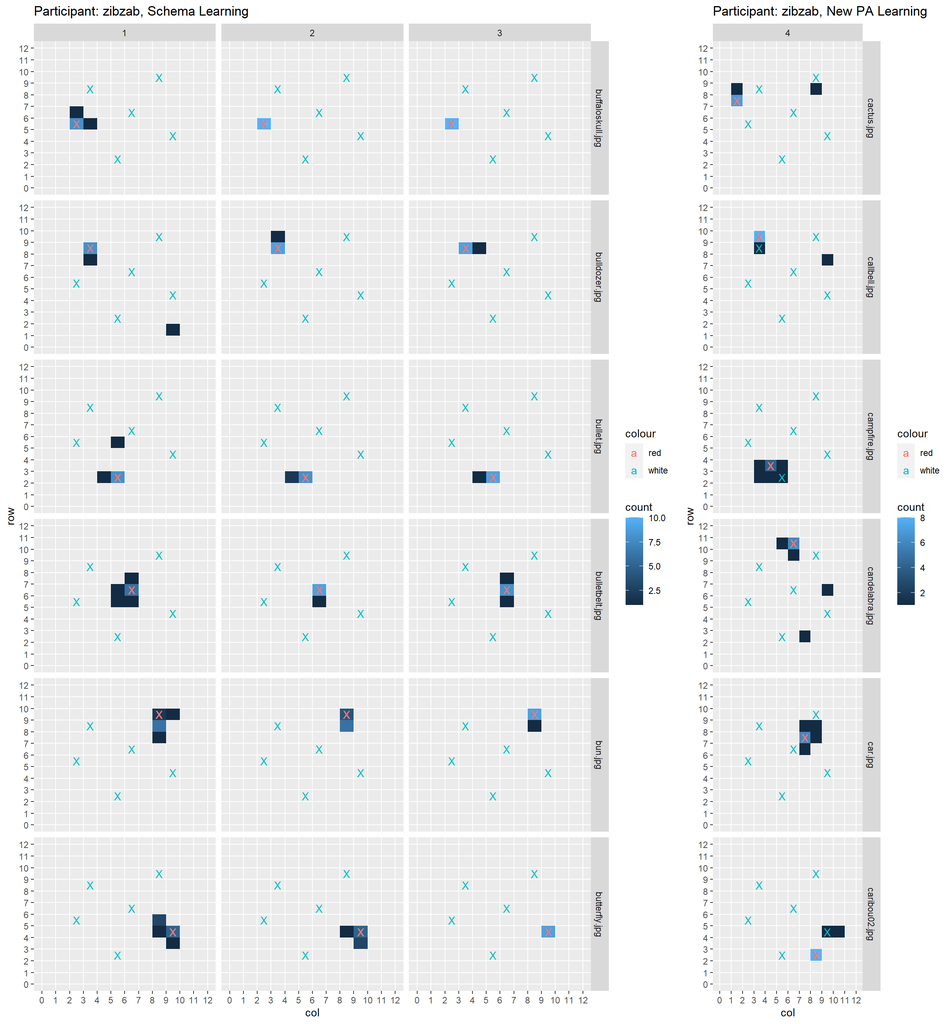

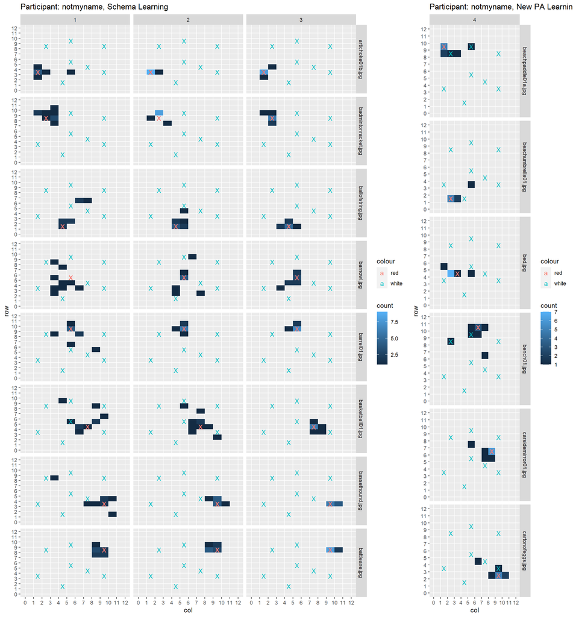

Table 3.1: Participant: 48652

| stimulus_name | session_global | avg_corr | avg_roughly_corr |
| --- | --- | --- | --- |
| buffaloskull.jpg | 1 | 0.3 | 0.6 |
| buffaloskull.jpg | 2 | 0.6 | 1.0 |
| buffaloskull.jpg | 3 | 0.9 | 1.0 |
| bulldozer.jpg | 1 | 0.3 | 0.6 |
| bulldozer.jpg | 2 | 0.7 | 0.9 |
| bulldozer.jpg | 3 | 0.4 | 0.9 |
| bullet.jpg | 1 | 0.6 | 0.8 |
| bullet.jpg | 2 | 0.6 | 1.0 |
| bullet.jpg | 3 | 1.0 | 1.0 |
| bulletbelt.jpg | 1 | 0.3 | 1.0 |
| bulletbelt.jpg | 2 | 0.8 | 1.0 |
| bulletbelt.jpg | 3 | 0.9 | 1.0 |
| bun.jpg | 1 | 0.7 | 1.0 |
| bun.jpg | 2 | 0.8 | 1.0 |
| bun.jpg | 3 | 0.5 | 1.0 |
| butterfly.jpg | 1 | 0.5 | 0.8 |
| butterfly.jpg | 2 | 0.5 | 1.0 |
| butterfly.jpg | 3 | 1.0 | 1.0 |
| cactus.jpg | 4 | 0.3 | 0.7 |
| callbell.jpg | 4 | 0.7 | 0.9 |
| campfire.jpg | 4 | 0.5 | 0.8 |
| candelabra.jpg | 4 | 0.7 | 0.8 |
| car.jpg | 4 | 0.5 | 0.7 |
| caribou02.jpg | 4 | 0.5 | 0.8 |

Table 3.1: Participant: zibzab

| stimulus_name | session_global | avg_corr | avg_roughly_corr |
| --- | --- | --- | --- |
| buffaloskull.jpg | 1 | 0.8 | 1.0 |
| buffaloskull.jpg | 2 | 1.0 | 1.0 |
| buffaloskull.jpg | 3 | 1.0 | 1.0 |
| bulldozer.jpg | 1 | 0.8 | 0.9 |
| bulldozer.jpg | 2 | 0.9 | 1.0 |
| bulldozer.jpg | 3 | 0.9 | 1.0 |
| bullet.jpg | 1 | 0.8 | 0.9 |
| bullet.jpg | 2 | 0.8 | 1.0 |
| bullet.jpg | 3 | 0.9 | 1.0 |
| bulletbelt.jpg | 1 | 0.6 | 1.0 |
| bulletbelt.jpg | 2 | 0.9 | 1.0 |
| bulletbelt.jpg | 3 | 0.8 | 1.0 |
| bun.jpg | 1 | 0.2 | 0.9 |
| bun.jpg | 2 | 0.4 | 1.0 |
| bun.jpg | 3 | 0.9 | 1.0 |
| butterfly.jpg | 1 | 0.5 | 1.0 |
| butterfly.jpg | 2 | 0.5 | 0.9 |
| butterfly.jpg | 3 | 0.9 | 0.9 |
| cactus.jpg | 4 | 0.7 | 0.9 |
| callbell.jpg | 4 | 0.8 | 0.9 |
| campfire.jpg | 4 | 0.4 | 0.9 |
| candelabra.jpg | 4 | 0.6 | 0.8 |
| car.jpg | 4 | 0.6 | 1.0 |
| caribou02.jpg | 4 | 0.8 | 0.8 |

Table 3.1: Participant: notmyname

| stimulus_name | session_global | avg_corr | avg_roughly_corr |
| --- | --- | --- | --- |
| artichoke01b.jpg | 1 | 0.4 | 0.9 |
| artichoke01b.jpg | 2 | 0.9 | 1.0 |
| artichoke01b.jpg | 3 | 0.8 | 1.0 |
| badmintonracket.jpg | 1 | 0.1 | 0.9 |
| badmintonracket.jpg | 2 | 0.0 | 1.0 |
| badmintonracket.jpg | 3 | 0.6 | 1.0 |
| ballofstring.jpg | 1 | 0.2 | 0.7 |
| ballofstring.jpg | 2 | 0.4 | 0.9 |
| ballofstring.jpg | 3 | 0.5 | 1.0 |
| barnowl.jpg | 1 | 0.0 | 0.2 |
| barnowl.jpg | 2 | 0.4 | 0.5 |
| barnowl.jpg | 3 | 0.3 | 0.9 |
| barrel01.jpg | 1 | 0.4 | 0.7 |
| barrel01.jpg | 2 | 0.6 | 1.0 |
| barrel01.jpg | 3 | 0.7 | 1.0 |
| basketball01.jpg | 1 | 0.1 | 0.6 |
| basketball01.jpg | 2 | 0.1 | 0.7 |
| basketball01.jpg | 3 | 0.6 | 1.0 |
| bassethound.jpg | 1 | 0.2 | 0.6 |
| bassethound.jpg | 2 | 0.4 | 1.0 |
| bassethound.jpg | 3 | 0.6 | 1.0 |
| battleaxe.jpg | 1 | 0.2 | 1.0 |
| battleaxe.jpg | 2 | 0.3 | 1.0 |
| battleaxe.jpg | 3 | 0.8 | 1.0 |
| beachpaddle01a.jpg | 4 | 0.5 | 0.8 |
| beachumbrella01.jpg | 4 | 0.5 | 0.9 |
| bed.jpg | 4 | 0.1 | 0.8 |
| bench01.jpg | 4 | 0.3 | 0.8 |
| carsidemirror01.jpg | 4 | 0.6 | 0.9 |
| cartonofeggs.jpg | 4 | 0.5 | 0.9 |